```python
# Import Packages
import numpy as np
import pandas as pd
import seaborn as sns
import statistics
from sklearn.preprocessing import MinMaxScaler, StandardScaler, RobustScaler
```

# DTSC 2301 Coding Demo: Data Cleaning and Preparation

**Table of contents**

- DTSC 2301 Coding Demo: Data Cleaning and Preparation
  - Part 1: Type Casting in Pandas
  - Part 2: Categorical Data Sanity Check
  - Part 3: Outlier Identification and Management:
  - A Tangent:
  - Part 4: Missing Data/Outlier Management:
    - Part 4.1: Identifying Missing Values
  - Back to Part 4:
    - Option 1: Remove Column Entirely
    - Option 2: Imputation
    - Option 3: Use a Model to Impute Missing Values
  - Part 5: One-Hot Encoding
  - Part 6: Scaling (Time Permitting)
    - Part 6.1: Min-Max Scaling
    - Part 6.2: Z-Score Normalization (Standardization)
    - Part 6.3: Robust Scaling

```python
# Load dataset
pat_data=pd.read_csv("ps2_logistic_public.csv", dtype={"Zip3": "string"})
pat_data_1=pat_data.copy()
```

## Part 1: Type Casting in Pandas

Let's take a look at our dataframe and see what our data looks like.

```python
# Look at the first five rows
pat_data.head()
```

|  | treatment | age | blood_pressure | gender | blood_test | family_history | MeasureA | TestB | GeneA | GeneB | GeneC | Zip3 | age_with_na |
| --- | --- | --- | --- | --- | --- | --- | --- | --- | --- | --- | --- | --- | --- |
| 0 | 1 | 74 | 94.113373 | non-female | negative | False | -11.035690 | -0.336843 | double | 1 | 0 | 421 | 74.0 |
| 1 | 1 | 56 | 83.337745 | non-female | negative | False | -3.982345 | -0.018734 | none | 1 | 1 | 141 | 56.0 |
| 2 | 0 | 37 | 81.759240 | female | negative | False | 6.205701 | 0.147933 | double | 1 | 1 | 181 | NaN |
| 3 | 1 | 54 | 88.549518 | female | negative | False | -1.827613 | -0.338373 | none | 1 | 1 | 083 | NaN |
| 4 | 0 | 73 | 82.171555 | female | negative | NaN | -14.637389 | -0.369325 | none | 1 | 1 | 822 | NaN |

```python
# Get information about datatypes
pat_data.info()
```

```
<class 'pandas.DataFrame'>
RangeIndex: 10000 entries, 0 to 9999
Data columns (total 13 columns):
 #   Column          Non-Null Count  Dtype
---  ------          --------------  -----
 0   treatment       10000 non-null  int64
 1   age             10000 non-null  int64
 2   blood_pressure  10000 non-null  float64
 3   gender          10000 non-null  str
 4   blood_test      10000 non-null  str
 5   family_history  7068 non-null   object
 6   MeasureA        10000 non-null  float64
 7   TestB           10000 non-null  float64
 8   GeneA           10000 non-null  str
 9   GeneB           10000 non-null  int64
 10  GeneC           10000 non-null  int64
 11  Zip3            10000 non-null  string
 12  age_with_na     7003 non-null   float64
dtypes: float64(4), int64(4), object(1), str(3), string(1)
memory usage: 1015.8+ KB
```

**Question**: Do you notice anything strange?

## Part 2: Categorical Data Sanity Check

**Question**: How do you know that your categorical data is correct? What can create differences in your data?

You know your categorical data is correct if the value makes sense for example, gender should include male or female. Interpretation error can create differences in the data. Case sensitivity, can also create differnces.

```python
pat_data["gender"].unique()
```

```
<StringArray>
['non-female', 'female']
Length: 2, dtype: str
```

```python
# Identify categorical columns:
cat_cols = [
    "blood_test",
    "GeneA",
    "gender"
    ]


# Create a for loop that prints unique values in each categorical column in form "Column_name : [list of unique values]"
for cat in cat_cols:
    print(cat, ":", pat_data[cat].unique())
```

```
blood_test : <StringArray>
['negative', 'positive']
Length: 2, dtype: str
GeneA : <StringArray>
['double', 'none', 'single']
Length: 3, dtype: str
gender : <StringArray>
['non-female', 'female']
Length: 2, dtype: str
```

## Part 3: Outlier Identification and Management:

What is an outlier?

An outlier is a data point that is significantly different from the majorityof the data in the dataset. This can happen due to measurement errors, natural variablility or data manipulation.

Outliers can distort statistical measures, leading to biased or misleading results. Handling outliers is essential to improve the efficacy of statistical analysis and the reliability of insights.

**Question**: What plots can help us find outliers?

Scatter plots, hisotgrams, cat plots

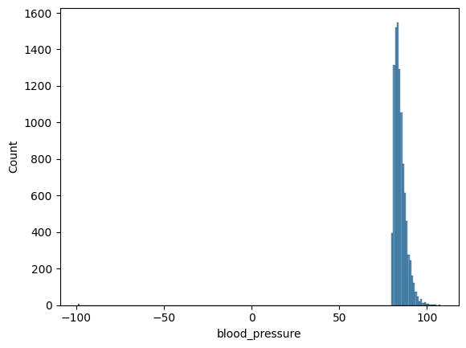

```python
sns.histplot(x="blood_pressure", data=pat_data)
```

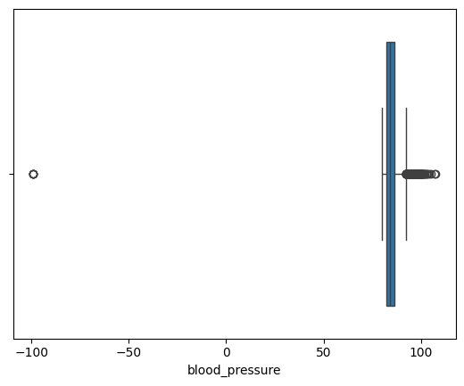

```python
sns.boxplot(data=pat_data, x="blood_pressure")
```

Sometimes, identifying outliers is harder to find by looking at a chart. For this approach it is easier to use the Tukey Outlier Method which identifies outliers using the Interquartile Range (IQR).

The outlier is calculated by using [Q1-1.5 * IQR, Q3+1.5 * IQR], inclusive

```python
# Calculate IQR
q1=np.percentile(pat_data["blood_pressure"], 25)
q3=np.percentile(pat_data["blood_pressure"], 75)

iqr = q3 - q1
# Calculate Threshold
threshold = 1.5 * iqr

lb=q1 - threshold
ub=q3 + threshold
# Identify Outliers
outliers = pat_data[(pat_data["blood_pressure"] <= lb) | (pat_data["blood_pressure"] >= ub)]

print("There are ", len(outliers), "Outliers for Blood Pressure")
```

```
There are  305 Outliers for Blood Pressure
```

```python
# Do the same for age
# Calculate IQR
q1=np.percentile(pat_data["age"], 25)
q3=np.percentile(pat_data["age"], 75)

iqr = q3 - q1
# Calculate Threshold
threshold = 1.5 * iqr

lb=q1 - threshold
ub=q3 + threshold
# Identify Outliers
outliers = pat_data[(pat_data["age"] <= lb) | (pat_data["age"] >= ub)]

print("There are ", len(outliers), "Outliers for Age")
```

```
There are  73 Outliers for Age
```

## A Tangent:

**QUESTION**: Mean vs Median: When should we use each metric?

Use the median for skewed data, the mean is for the average (it follows normal assumptions)

## Part 4: Missing Data/Outlier Imputation:

### Part 4.1: Identifying Missing Values

Before we talk about handling outliers, let's talk about how to identify missing data.

```python
# Check how much data is missing
pat_data.isnull().sum()
```

```
treatment            0
age                  0
blood_pressure       0
gender               0
blood_test           0
family_history    2932
MeasureA             0
TestB                0
GeneA                0
GeneB                0
GeneC                0
Zip3                 0
age_with_na       2997
dtype: int64
```

## Back to Part 4:

Now that we have identified outliers and missing data, let's talk about what we can do.

### Option 1: Remove Column Entirely

```python
# Remove "family_history" column DO NOT ACTUALLY RUN THIS CELL WHEN YOU COMPLETE IT
# pat_data.drop(columns = ["family_history"])

# pat_data = pat_data.drop("family_history", axis=1)

# pat_data.drop("family_history", axis=1, inplace=True)
```